# Analysis for *Practice Changes at U.S. Transplant Centers After the New Adult Heart Allocation Policy*

Kevin Chung, William Parker

# Preparation for analysis

## Loading in packages

This chunk is used to load in the packages in R that help us to tidy, manipulate, and visualize the data.

```r
library(tidyverse)
library(nnet)
library(rmdformats)
```

## Loading in Final_Sample file

The file being uploaded is the same file that was the output of the data_preparation rmd.

```r
final_sample <- read_csv("final_sample.csv")

# Read data in
final_sample <- read_csv("final_sample.csv") %>%
  mutate(month = zoo::as.yearmon(list_date),
         treatment = factor(treatment,
                            levels = c("None", "Exception",
                                       "Low-dose Inotropes", "LVAD",
                                       "High-dose Inotropes", "IABP",
                                        "Other MCS", "ECMO"))
  )


start_date <- as.Date("2017-12-1")

end_date <- as.Date("2019-4-30")

#mark the end of the pre-policy cohort
pre_policy_end_date <- end_date - lubridate::years(1)

#mark the start of the post-policy cohort
transition_date <- start_date + lubridate::years(1)


pre_policy_period <- paste0(format(start_date, "%b %Y"), " - ", format(pre_policy_end_date, "%b %Y"), " (Pre-Policy)")

post_policy_period <- paste0(format(transition_date, "%b %Y"), " - ", format(end_date, "%b %Y"), " (Post-policy)")



policy_switch_date <- as.Date("2018-10-18")
```

## Creating functions

We created some functions in order to make our code more concise.

```r
comma <- function(x){
  case_when(
    abs(x) > 10 ~ format(x, digits = 0, big.mark = ","),
    abs(x) > 1 ~ format(x, digits = 2, big.mark = ","),
    TRUE ~ format(x, digits = 2, big.mark = ",")
  )

}

comma_p <- function(x){
  case_when(
    x < 0.001 ~ "p<0.001",
    x < 0.01 ~ paste0("p=" ,format(x, digits = 1, big.mark = ",")),
    TRUE ~ paste0("p=" ,format(x, digits = 2, big.mark = ","))
  )
}


rates_by_policy_diff <- function(name, final_sample){

  df <- final_sample %>%
    group_by(policy) %>%
    filter(!is.na(policy)) %>%
    count(treatment) %>%
    mutate(total_treated = sum(n),
           percent_treated = 100*n/total_treated) %>%
    filter(treatment == name)

  pre <- df[1,]
  post <- df[2,]

  a <- prop.test(x = c(post$n, pre$n), n = c( post$total_treated, pre$total_treated))

  low_ci <- 100*a$conf.int[1]

  up_ci <- 100*a$conf.int[2]

  post <- df$percent_treated[[2]]

  pre <- df$percent_treated[[1]]

  diff <- (post - pre)

  #paste0(name, "%; 95% CI ", comma(low_ci), "% to ", comma(up_ci), "%).")
  paste0(name, " was used to list ", comma(pre), "% of candidates in the 3-tier system to ", comma(post), "% candidates in the 6-tier system (absolute difference ", comma(diff), "%; 95% CI ", comma(low_ci), "% to ", comma(up_ci), "%).")

}


paragraph <- ""


for (name in levels(final_sample$treatment)){
  paragraph <- paste0(paragraph, " ", rates_by_policy_diff(name, final_sample))
}
```

```r
rates_by_policy_diff_status <- function(name, final_sample){

  df <- final_sample %>%
    group_by(policy) %>%
    filter(!is.na(policy)) %>%
    count(status) %>%
    mutate(total_treated = sum(n),
           percent_treated = 100*n/total_treated) %>%
    filter(status == name)

  pre <- df[1,]
  post <- df[2,]

  a <- prop.test(x = c(post$n, pre$n), n = c( post$total_treated, pre$total_treated))

  low_ci <- 100*a$conf.int[1]

  up_ci <- 100*a$conf.int[2]

  post <- df$percent_treated[[2]]

  pre <- df$percent_treated[[1]]

  diff <- (post - pre)

  paste0(name, " was used to list ", comma(pre), "% of candidates in the pre-policy cohort and ", comma(post), "% candidates in the post-policy cohort (absolute difference ", comma(diff), "%; 95% CI ", comma(low_ci), "% to ", comma(up_ci), "%).")

}

paragraph_status <- ""


for (name in levels(factor(final_sample$status))){
  paragraph_status <- paste0(paragraph_status, " ", rates_by_policy_diff_status(name, final_sample))
}


absolute_diff_count <- function(name, x, group_var, final_sample){

  group_var <- enquo(group_var)
  x <- enquo(x)

  df <- final_sample %>%
    group_by(!! group_var) %>%
    filter(!is.na(!! group_var)) %>%
    count(!! x) %>%
    mutate(total_treated = sum(n),
        percent_treated = 100*n/total_treated) %>%
    filter(!!x == name)


  pre <- df[1,]
  post <- df[2,]

  a <- prop.test(x = c(post$n, pre$n), n = c( post$total_treated, pre$total_treated))

  low_ci <- 100*a$conf.int[1]

  up_ci <- 100*a$conf.int[2]

  post <- df$percent_treated[[2]]

  pre <- df$percent_treated[[1]]

  diff <- (post - pre)

  #this text can be customized to according to the variable of interest
  paste0(comma(pre), "% of candidates in the pre-policy cohort ", comma(post), "% to candidates in the post-policy cohort (absolute difference ", comma(diff), "%; 95% CI ", comma(low_ci), "% to ", comma(up_ci), "%)")

}
pre_policy_counts <- final_sample %>%
  filter(policy == pre_policy_period) %>%
  group_by(status) %>%
  count() %>%
  ungroup() %>%
  mutate(total = sum(n),
         pct_total = paste0(comma(100*n/total), "%"))


post_policy_counts <- final_sample %>%
  filter(policy == post_policy_period) %>%
  group_by(status) %>%
  count() %>%
  ungroup() %>%
  mutate(total = sum(n),
         pct_total = paste0(comma(100*n/total), "%"))
```

# Table 1: Candidate demographics and clinical characteristics by policy period

```r
cand_thor <- haven::read_sas("cand_thor.sas7bdat", NULL)# loading in "cand_thor"

for_table_1 <- final_sample %>%
  select(policy, PX_ID) %>%
  filter(is.na(policy) == FALSE) %>%
  left_join(cand_thor) %>%
  filter(PX_ID %in% final_sample$PX_ID) %>%
   mutate(age = CAN_AGE_AT_LISTING,
         female = ifelse(CAN_GENDER == "F", 1, 0),
         race = factor(CAN_RACE),
         race = fct_lump(race, n = 3),
         race = fct_recode(race,
                          "White" = "8",
                          "Black" = "16",
                          "Hispanic" = "2000",
                          "Other" = "Other"),
         bmi = CAN_BMI,
        simple_diagnosis = case_when(
          CAN_DGN>999 & CAN_DGN<1007 ~ "Dilated cardiomyopathy, non-ischemic",
          CAN_DGN == 1007 | CAN_DGN ==1200 ~ "Ischemic cardiomyopathy",
          CAN_DGN>1048 & CAN_DGN< 1100 ~ "Restrictive cardiomyopathy",
          TRUE ~ "Other"
        ),
        "Diagnosis" = factor(simple_diagnosis,
                           levels = c("Dilated cardiomyopathy, non-ischemic",
                                      "Ischemic cardiomyopathy",
                                      "Restrictive cardiomyopathy",
                                      "Other")),
        diabetes = case_when(
          CAN_DIAB_TY>1 & CAN_DIAB_TY<6 ~ "History of DM",
          CAN_DIAB_TY ==1 ~ "Non-diabetic",
          TRUE ~ "Unknown"
        ),
        diabetes = factor(diabetes),
        female_gfr = if_else(CAN_GENDER == "F", 0.742, 1),
        black_gfr = if_else(race == "Black", 1.21, 1),
        eGFR = 175*((CAN_MOST_RECENT_CREAT)^(-1.154))*(CAN_AGE_AT_LISTING^(-0.203))*female_gfr*black_gfr,
        functional_status = case_when(
          CAN_FUNCTN_STAT == 1 | (CAN_FUNCTN_STAT>2069) ~"Limited Impairment, 100-70%",
          CAN_FUNCTN_STAT ==2 | (CAN_FUNCTN_STAT>2049 & CAN_FUNCTN_STAT<2061) ~ "Moderate Impairment, 50-60%",
          CAN_FUNCTN_STAT == 3 | (CAN_FUNCTN_STAT>2000 & CAN_FUNCTN_STAT<2041) ~ "Severe Impairment ≥ 40%%",
          TRUE ~ "Unknown"
        ),
        functional_status = ifelse(is.na(functional_status), "Unknown", functional_status),
        functional_status = factor(functional_status),
        pcwp = CAN_PCW_MEAN,
        body_surface_area = 0.007184*(CAN_HGT_CM)^(0.725)*CAN_WGT_KG^(0.425),
        cardiac_index = as.numeric(CAN_CARDIAC_OUTPUT/body_surface_area),
        cardiac_index = ifelse(cardiac_index>10, NA, cardiac_index),
        blood_type = factor(
           case_when(
             CAN_ABO %in% c("A", "A1", "A2") ~ "A",
             CAN_ABO %in% c("A1B", "A2B") ~ "AB",
             TRUE ~ CAN_ABO)
           ),
        payor = case_when(
          CAN_PRIMARY_PAY %in% c(3,4,13) ~ "Medicare",
          CAN_PRIMARY_PAY ==2 ~ "Medicaid",
          CAN_PRIMARY_PAY == 1 ~ "Private",
          TRUE ~ "Other"
        ),
        History_of_Smoking = case_when(
           CAN_HIST_CIGARETTE == "Y" ~ "Smoking history",
           CAN_HIST_CIGARETTE == "N" ~ "No prior smoking history"),
        Working = case_when(
           CAN_WORK_INCOME == "N" ~ "Not working",
           CAN_WORK_INCOME == "Y" ~ "Working"),
        Education_Status = case_when(
          CAN_EDUCATION %in% c(4,5,6) ~ "College",
          CAN_EDUCATION == 3 ~ "High School",
          TRUE ~ "Less than high school or unknown"
        ),
  ) %>%
  select(PX_ID, policy, #patient ID and listing status
         age, female, race, #basic demographics
         History_of_Smoking, Working, Education_Status,
         bmi, blood_type, "Diagnosis", eGFR, diabetes, functional_status, #diagnosis and medical comorbidities, some factor variables some continuous
         cardiac_index, pcwp, #hemodynamics
         payor, #payor
         #ecmo, iabp, lvad, other_mcs, high_dose_inotropes, low_dose_inotropes #treatments- hot coded
         ) %>%
  mutate_if(is.character, factor)

haven::write_dta(for_table_1, "for_table_1.dta")
```

```r
myvars <- names(for_table_1 %>% select(-PX_ID, -policy))
tableone::CreateTableOne(data = for_table_1, myvars, strata ="policy", smd = TRUE)
```

```
##                                           Stratified by policy
##                                            Dec 2017 - Apr 2018 (Pre-Policy)
##   n                                         1606
##   age (mean (SD))                          53.04 (12.82)
##   female (mean (SD))                        0.28 (0.45)
##   race (%)
##      White                                  1041 (64.8)
##      Black                                   349 (21.7)
##      Hispanic                                146 ( 9.1)
##      Other                                    70 ( 4.4)
##   History_of_Smoking = Smoking history (%)   702 (43.7)
##   Working = Working (%)                      310 (19.9)
##   Education_Status (%)
##      College                                 905 (56.4)
##      High School                             588 (36.6)
##      Less than high school or unknown        113 ( 7.0)
##   bmi (mean (SD))                          27.90 (5.07)
##   blood_type (%)
##      A                                       567 (35.3)
##      AB                                       77 ( 4.8)
##      B                                       248 (15.4)
##      O                                       714 (44.5)
##   Diagnosis (%)
##      Dilated cardiomyopathy, non-ischemic    670 (41.7)
##      Ischemic cardiomyopathy                 496 (30.9)
##      Restrictive cardiomyopathy              220 (13.7)
##      Other                                   220 (13.7)
##   eGFR (mean (SD))                         64.89 (27.58)
##   diabetes (%)
##      History of DM                           468 (29.1)
##      Non-diabetic                           1138 (70.9)
##      Unknown                                   0 ( 0.0)
##   functional_status (%)
##      Limited Impairment, 100-70%             422 (26.3)
##      Moderate Impairment, 50-60%             400 (24.9)
##      Severe Impairment ≥ 40%%              761 (47.4)
##      Unknown                                  23 ( 1.4)
##   cardiac_index (mean (SD))                 2.21 (0.62)
##   pcwp (mean (SD))                         17.98 (8.77)
##   payor (%)
```

[output cut: 77 more lines]

```
##      History of DM
##      Non-diabetic
##      Unknown
##   functional_status (%)                    <0.001
##      Limited Impairment, 100-70%
##      Moderate Impairment, 50-60%
##      Severe Impairment ≥ 40%%
##      Unknown
##   cardiac_index (mean (SD))                 0.010
##   pcwp (mean (SD))                          0.547
##   payor (%)                                <0.001
##      Medicaid
##      Medicare
##      Other
##      Private
```

Summary statistics for candidate characteristics of both the pre and post-policy cohort. At a p-value threshold of 0.05. We want to emphasize that this table lists the mean. The table in the article uses median and was produced in Stata.

# Figure 1: Trends in treatments used to list adult heart transplant candidates during the transition to the new heart allocation policy

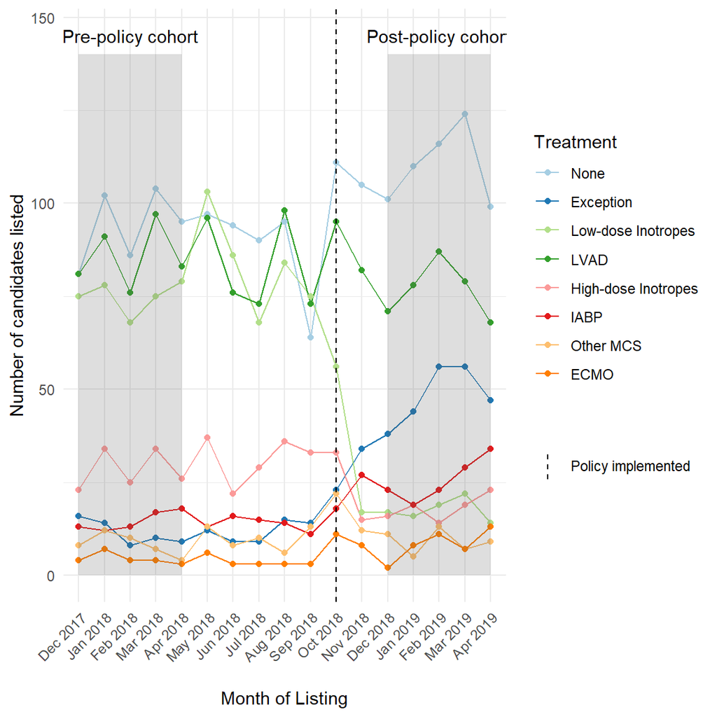

```r
treatment_pal <- "Paired"
treatment_pal_dir <- 1

by_month <- final_sample %>%
  group_by(policy, month) %>%
  count(treatment) %>%
  mutate(total_per_month = sum(n)) %>%
    ungroup () %>%
  mutate(month = factor(month),
         percentage_per_month = 100*n/total_per_month)

policy_switch <- which(levels(by_month$month) == "Oct 2018")

pre_policy_start <- which(levels(by_month$month) == "Dec 2017")

pre_policy_end <- which(levels(by_month$month) == "Apr 2018")

post_policy_start <- which(levels(by_month$month) == "Dec 2018")

post_policy_end <- which(levels(by_month$month) == "Apr 2019")


ggplot(by_month, aes(x = month, y = n, color = treatment, group = treatment)) +
  geom_line() +
  geom_point() +
  geom_vline(aes(xintercept = policy_switch, linetype = "Policy implemented")) +
  scale_color_brewer(palette=treatment_pal, direction = treatment_pal_dir) +
  labs(
    x = "Month of Listing",
    y = "Number of candidates listed",
    linetype = "",
    color = "Treatment") +
    theme_minimal() +
    theme(axis.text.x = element_text(angle = 45, hjust = 1),
          axis.title.x = element_text(margin = margin(t = 15, r = 0, b = 0, l = 0))
          ) +
  scale_linetype_manual(values = c("dashed", "dotted", "solid")) +
  scale_fill_manual(values = c("gray", "darkgray")) +
  annotate("text", x = which(levels(by_month$month)== "Feb 2018"), y = 145, label= "Pre-policy cohort") +
  annotate("text", x = which(levels(by_month$month)== "Feb 2019"), y = 145, label= "Post-policy cohort") +
  annotate("rect",
           xmin = which(levels(by_month$month)== "Dec 2017"),
           xmax = which(levels(by_month$month)== "Apr 2018"),
           ymin = 0, ymax = 140,  alpha = 0.2)+
  annotate("rect",
           xmin = which(levels(by_month$month)== "Dec 2018"),
           xmax = which(levels(by_month$month)== "Apr 2019"),
           ymin = 0, ymax = 140, alpha = 0.2)
```

```r
#ggsave("Figure_1.pdf")
ggsave("Figure_1.tiff", dpi = "print", width = 7.29, height = 4.51)
```

Trends in the number of candidates listed by month, stratified by treatment at initial listing. Adult heart candidates only.

# Table 2: Treatment rates by policy period

This table allows us to see how treatment practices have changed before and after the policy change.

```r
pre_total <- final_sample %>%
  filter(policy == !! pre_policy_period) %>%
  nrow()

post_total <- final_sample %>%
  filter(policy == !! post_policy_period) %>%
  nrow()

for_ci <- final_sample %>%
  filter(!is.na(policy)) %>%
  group_by(policy) %>%
  count(treatment) %>%
  pivot_wider(names_from = policy, values_from =n)


prop_wrapper <- function(name, for_ci, pre_policy_period, post_policy_period){
  df <- for_ci %>%
    filter(treatment == name)

  pre <- df[pre_policy_period][[1]]

  post <- df[post_policy_period][[1]]

  test <- prop.test(x = c(post, pre), n = c(post_total, pre_total))

  diff <- test$estimate


  pre_policy <- paste0(comma(pre)," (", comma(100*diff[2]), ")")

  post_policy <-paste0(comma(post), " (", comma(100*diff[1]), ")")

  low_ci <- test$conf.int[1]
  up_ci <- test$conf.int[2]

  ci <- paste0("[95% CI, ", comma(100*low_ci), "% to ", comma(100*up_ci), "%]")

  abs_diff_pct = paste0(comma(100*diff[1] - 100*diff[2]), "%")

  change <- paste0(abs_diff_pct, " ", ci)

  output <- tibble(
    treatment = name,
    !!pre_policy_period := pre_policy,
    !!post_policy_period :=  post_policy,
    `absolute difference (%)` = change)

  return(output)
}


table_2 <-
  tibble(
    treatment = "",
    `absolute difference (%)` = "",
    !!pre_policy_period := paste0("N = ", pre_total),
    !!post_policy_period := paste0("N = ", post_total)
  ) %>% rbind(map_dfr(levels(final_sample$treatment), ~ prop_wrapper(.x, for_ci, pre_policy_period, post_policy_period))) %>%
  select(treatment, !! pre_policy_period,  !! post_policy_period, `absolute difference (%)`)

write_csv(table_2, "table2.csv")

knitr::kable(table_2)
```

| treatment | Dec 2017 - Apr 2018 (Pre-Policy) | Dec 2018 - Apr 2019 (Post-policy) | absolute difference (%) |
| --- | --- | --- | --- |
|  | N = 1606 | N = 1567 |  |
| None | 468 (29) | 550 (35) | 6% [95% CI, 2.7% to 9.3%] |
| Exception | 57 (3.5) | 241 (15) | 12% [95% CI, 9.8% to 14%] |
| Low-dose Inotropes | 375 (23) | 88 (5.6) | -18% [95% CI, -20% to -15%] |
| LVAD | 428 (27) | 383 (24) | -2.2% [95% CI, -5.3% to 0.89%] |
| High-dose Inotropes | 142 (8.8) | 91 (5.8) | -3% [95% CI, -4.9% to -1.2%] |
| IABP | 73 (4.5) | 128 (8.2) | 3.6% [95% CI, 1.9% to 5.4%] |
| Other MCS | 41 (2.6) | 45 (2.9) | 0.32% [95% CI, -0.88% to 1.5%] |
| ECMO | 22 (1.4) | 41 (2.6) | 1.2% [95% CI, 0.21% to 2.3%] |

```r
#table_2
```

# Figure 2: Predicted and Observed Status Distribution in the New US Heart Allocation System

The predicted status observation is how the candidates in the old priority system would be classified in the new priority system.

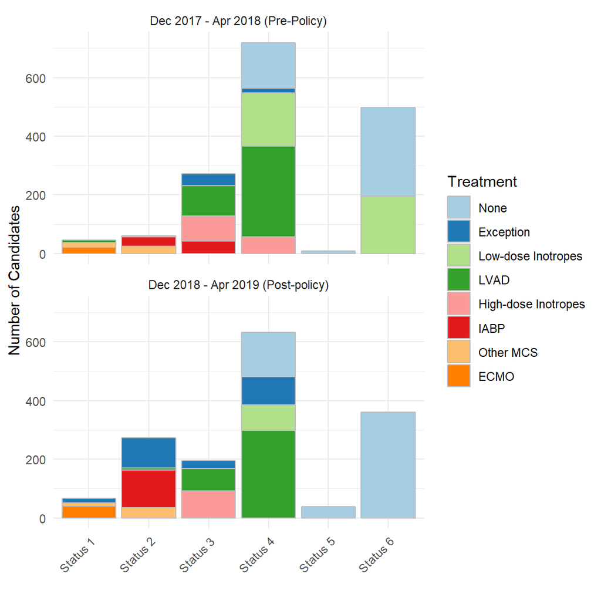

```r
ggplot(final_sample %>% filter(is.na(policy) == FALSE), aes(x = factor(status), fill = treatment)) +
  geom_bar(color = "gray") +
  facet_wrap(.~policy, nrow = 2) +
  labs(
    x = "",
    y = "Number of Candidates",
    fill = "Treatment") +
  scale_fill_brewer(palette=treatment_pal, direction = treatment_pal_dir, guide = guide_legend(reverse = FALSE)) +
  theme_minimal() +
    theme(axis.text.x = element_text(angle = 45, hjust = 1))
```

```r
#ggsave("Figure_2.pdf")
ggsave("Figure_2.tiff", dpi = "print", width = 7.29, height = 4.51)
```

# Figure 3: Trends in Adult Heart Transplant Candidates Subject to Hemodynamic Requirements in the New Heart Allocation System

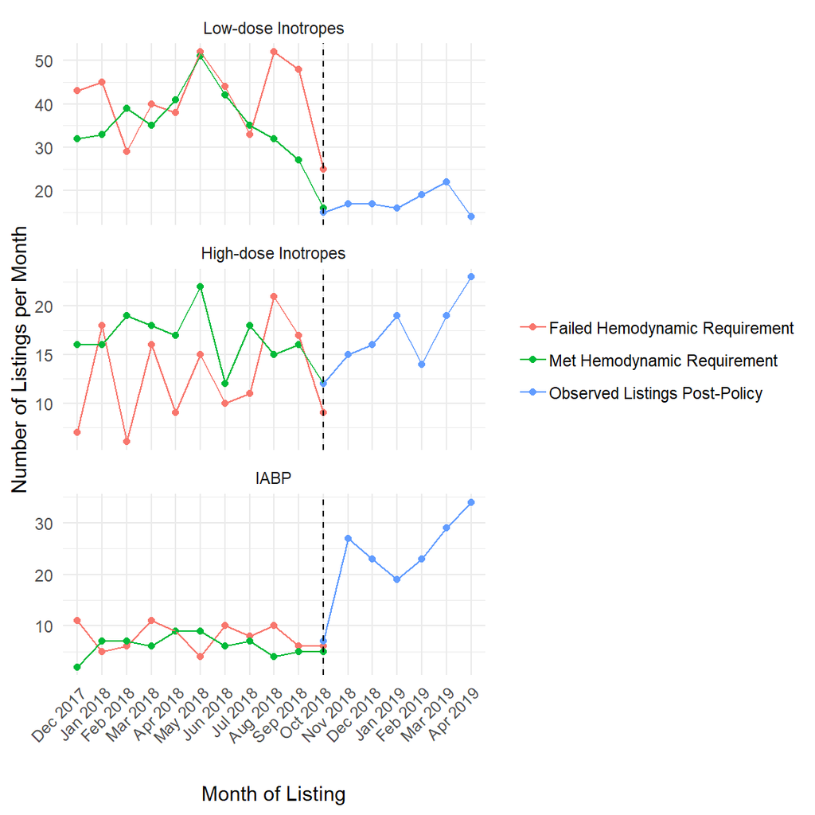

```r
shock_requirement <- final_sample %>%
  filter(treatment %in% c("Low-dose Inotropes", "High-dose Inotropes", "IABP", "ECMO"))%>%
   mutate(meet_shock = case_when(
    treatment == "IABP" & status == "Status 2" & CAN_INIT_STAT == 2010 ~ "Met Hemodynamic Requirement",
    treatment == "IABP" & status == "Status 3" & CAN_INIT_STAT == 2010 ~ "Failed Hemodynamic Requirement",
    treatment == "High-dose Inotropes" & status == "Status 3" & CAN_INIT_STAT == 2010 ~ "Met Hemodynamic Requirement",
    treatment == "High-dose Inotropes" & status == "Status 4" & CAN_INIT_STAT == 2010 ~ "Failed Hemodynamic Requirement",
    treatment == "ECMO" & status == "Status 3" & CAN_INIT_STAT == 2010 ~ "Failed Hemodynamic Requirement",
    treatment == "ECMO" & status == "Status 1" & CAN_INIT_STAT == 2010 ~ "Met Hemodynamic Requirement",
    treatment == "Low-dose Inotropes" & status == "Status 6" & CAN_INIT_STAT == 2020 ~ "Failed Hemodynamic Requirement",
    treatment == "Low-dose Inotropes" & status == "Status 4" & CAN_INIT_STAT == 2020 ~ "Met Hemodynamic Requirement",
    TRUE ~ "Observed Listings Post-Policy"
  ))

by_month_shock <- shock_requirement %>%
  filter(treatment != "ECMO") %>%
  group_by(month, treatment) %>%
  count(meet_shock) %>%
  ungroup() %>%
  mutate(month = factor(month))

every_other_month <- levels(by_month_shock$month)[c(TRUE, FALSE)]


ggplot(by_month_shock, aes(x = month, y = n, color = meet_shock, fill = meet_shock, group = meet_shock)) +
  facet_wrap(~treatment, nrow = 3, scales = "free_y") +
  geom_point() + geom_line() +
  geom_vline(aes(xintercept = policy_switch, linetype = "Policy implemented")) +
  labs(
    x = "Month of Listing",
    y = "Number of Listings per Month") +
    theme_minimal() +
    theme(axis.text.x = element_text(angle = 45, hjust = 1),
          axis.title.x = element_text(margin = margin(t = 20, r = 0, b = 0, l = 0)),
          legend.title = element_blank()) +
  scale_linetype_manual(values = c("dashed", "dotted", "solid"), guide = FALSE)
```

```r
ggsave("Figure_3.tiff", dpi = "print", width = 7.29, height = 4.51)
```

Number of candidates listed with low-dose inotropes, high-dose inotropes (with invasive hemodynamic monitoring), and IABP from Decemeber 2017 to April 2019. Listings prior to policy implementation are stratified by whether or not the candidates met the hemodynamic requirement for their respective therapy.

# Figure 4: Cardiac Index of Adult Heart Transplant Candidates subject to hemodynamic criteria in the new allocation system

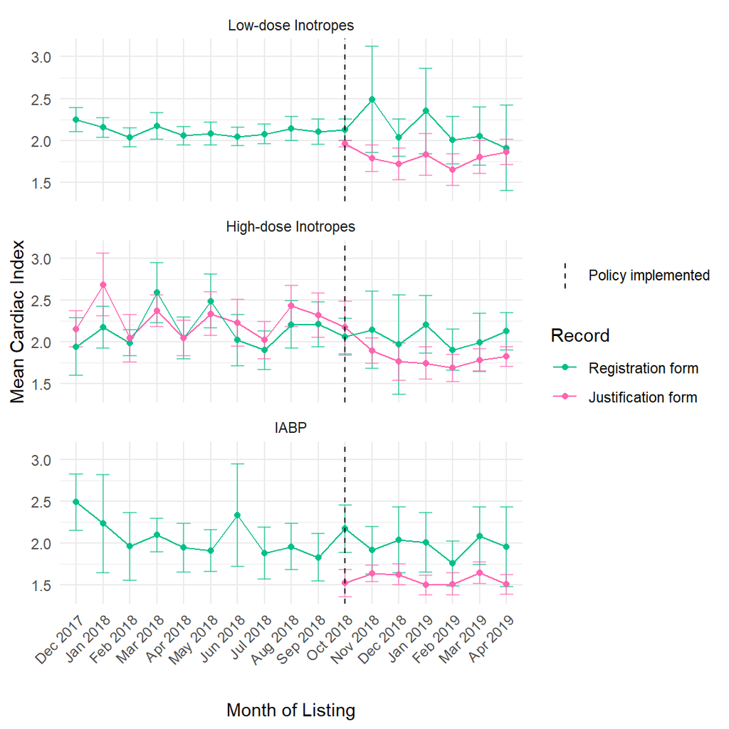

```r
shock_requirement %>%
  filter(treatment %in% c("Low-dose Inotropes", "High-dose Inotropes", "IABP")) %>%
  filter((CAN_CARDIAC_OUTPUT_MEDS == "Y" & just_measured_on_ino ==1) |
  (CAN_CARDIAC_OUTPUT_MEDS == "N" & just_measured_on_ino ==0)|
    is.na(just_measured_on_ino)) %>%
  group_by(month, treatment) %>%
  summarise(`Registration form` = mean(CI_list, na.rm = TRUE),
            sd_ci_list = sd(CI_list, na.rm = TRUE),
            n_ci_list = n(),
            `Justification form` = mean(CI_just, na.rm = TRUE),
            sd_ci_just = sd(CI_just, na.rm = TRUE),
            n_ci_just = n()) %>%
  ungroup() %>%
  mutate(month = factor(month)) %>%
  pivot_longer(cols = c("Registration form", "Justification form"),
               names_to = "Record",
               values_to = "Cardiac Index") %>%
  mutate(
    upper_ci = case_when(
      Record == "Registration form" ~ `Cardiac Index` + 1.96*sd_ci_list/sqrt(n_ci_list),
      TRUE ~ `Cardiac Index` + 1.96*sd_ci_just/sqrt(n_ci_just)
    ),
    lower_ci = case_when(
      Record == "Registration form" ~ `Cardiac Index` - 1.96*sd_ci_list/sqrt(n_ci_list),
      TRUE ~ `Cardiac Index` - 1.96*sd_ci_just/sqrt(n_ci_just)
    )
  ) %>%
ggplot(aes(x = month, y = `Cardiac Index`, ymin = lower_ci, ymax = upper_ci, color = `Record`, group = `Record`)) +
  geom_errorbar(alpha = 0.6, width = 0.5) +
  geom_line() +
  geom_point() +
  facet_wrap(~treatment, nrow = 3) +
  geom_vline(aes(xintercept = policy_switch, linetype = "Policy implemented")) +
  labs(
    x = "Month of Listing",
    y = "Mean Cardiac Index",
    linetype = "") +
    theme_minimal() +
    theme(axis.text.x = element_text(angle = 45, hjust = 1),
          axis.title.x = element_text(margin = margin(t = 20, r = 0, b = 0, l = 0))) +
  scale_linetype_manual(values = c("dashed", "dotted", "solid")) +
  scale_color_discrete(direction = -1, guide = guide_legend(reverse = TRUE))
```

```r
ggsave("Figure4.tiff", dpi = "print", width = 7.29, height = 4.51)
```

# Supplemental material

## Online Table 2: IPW multinomial logistic regression output

```r
for_regress <- for_table_1 %>%
  left_join(final_sample %>% select(treatment, status, PX_ID)) %>%
  select(-cardiac_index, -pcwp) %>%
  na.omit() %>%
  fastDummies::dummy_cols() %>%
  select(post = "policy_Dec 2018 - Apr 2019 (Post-policy)",
         treatment, policy,
         age,
         female,
         race_Black,
         Working_Working,
         Education_Status_College,
         smoking = "History_of_Smoking_Smoking history",
         bmi,
         blood_type_AB, blood_type_B, blood_type_O,
         restrictive_cm = "Diagnosis_Restrictive cardiomyopathy",
         dilated_cm = "Diagnosis_Dilated cardiomyopathy, non-ischemic",
         ischemic_cm = "Diagnosis_Ischemic cardiomyopathy",
         eGFR,
         diabetes_mellitus = "diabetes_History of DM",
         limited_impairment = "functional_status_Limited Impairment, 100-70%",
         moderate_impairment = "functional_status_Moderate Impairment, 50-60%",
         severe_impairement = "functional_status_Severe Impairment ≥ 40%%",
         payor_Medicaid, payor_Medicare, payor_Private)


ps_model <- glm("post ~ age + female + race_Black+ smoking + Working_Working + Education_Status_College + bmi + blood_type_AB + blood_type_B + blood_type_O + restrictive_cm + dilated_cm + ischemic_cm + eGFR + diabetes_mellitus + limited_impairment + moderate_impairment + severe_impairement + payor_Medicaid + payor_Medicare + payor_Private", data = for_regress, family = binomial())


predicted_policy <- tibble(p_post = predict(ps_model, type = "response"),
                           post = for_regress$post
                           ) %>% mutate(policy= case_when(
                             post == 1~ post_policy_period,
                             TRUE ~ pre_policy_period))


predicted_policy <- predicted_policy %>%
  mutate(ipw = case_when(
    policy == post_policy_period ~ 1/p_post,
    TRUE ~ 1/(1-p_post))
    )

for_regress["ipw"] <- predicted_policy$ipw
treat_reg <- multinom(treatment ~ post, data = for_regress, weights = predicted_policy$ipw)
summary(treat_reg)
```

```
## Call:
## multinom(formula = treatment ~ post, data = for_regress, weights = predicted_policy$ipw)
##
## Coefficients:
##                     (Intercept)       post
## Exception           -2.08558594  1.2403164
## Low-dose Inotropes  -0.15139634 -1.7252024
## LVAD                -0.05795144 -0.2936802
## High-dose Inotropes -1.06505518 -0.7356221
## IABP                -1.80661532  0.2556020
## Other MCS           -2.36644668 -0.1787043
## ECMO                -3.03236344  0.3934748
##
## Std. Errors:
##                     (Intercept)       post
## Exception            0.10332405 0.11731118
## Low-dose Inotropes   0.05052054 0.09764623
## LVAD                 0.04929375 0.06837263
## High-dose Inotropes  0.06783935 0.10555533
## IABP                 0.09145570 0.11689250
## Other MCS            0.11728238 0.16278427
## ECMO                 0.16017160 0.19889626
##
## Residual Deviance: 20638.14
## AIC: 20666.14
```

## Online Table 3: Adjusted treatment rates after IPW

```r
mean_data <- tibble(post = c(0,1))

predict(treat_reg, newdata = mean_data, "probs")
```

```
##        None  Exception Low-dose Inotropes      LVAD High-dose Inotropes
## 1 0.2794569 0.03471813         0.24019511 0.2637223          0.09633125
## 2 0.3554655 0.15265167         0.05442531 0.2500839          0.05871827
##         IABP  Other MCS       ECMO
## 1 0.04588933 0.02621682 0.01347026
## 2 0.07537041 0.02789025 0.02539468
```

```r
ipw_percentages <- predict(treat_reg, newdata = mean_data, "probs")


ipw_table <- tibble(treatment = levels(for_regress$treatment),
                    !! pre_policy_period := paste0(comma(100*ipw_percentages[1,]), " %"),
                    !! post_policy_period := paste0(comma(100*ipw_percentages[2,]), " %"))

# re-create propensity score weighted mlogitin Stata to use the convenient margins command. See see propensity_score_analysis.do
haven::write_dta(for_regress, "for_mlogit.dta")

diff_w_95_ci  <- read_csv("pre_post_diffs.csv") %>%
  mutate_at(c("absolute diff", "lower 95% CI", "upper 95% CI"), function(x) comma(100*x)) %>%
  mutate("absolute difference (%)" = paste0(`absolute diff`, "% [95% CI, ", `lower 95% CI`, "% to ", `upper 95% CI`, "%]"))

pre_ipw_total <- for_regress %>% filter(post == 0) %>% nrow()

post_ipw_total <- for_regress %>% filter(post == 1) %>% nrow()

knitr::kable(tibble(
    treatment = "",
    !!pre_policy_period := paste0("N = ", pre_ipw_total),
    !!post_policy_period := paste0("N = ", post_ipw_total),
        `absolute difference (%)` = ""
  ) %>% rbind(ipw_table %>%
                left_join(diff_w_95_ci %>% select(treatment, "absolute difference (%)"))
  ))
```

| treatment | Dec 2017 - Apr 2018 (Pre-Policy) | Dec 2018 - Apr 2019 (Post-policy) | absolute difference (%) |
| --- | --- | --- | --- |
|  | N = 1553 | N = 1481 |  |
| None | 28 % | 36 % | 7.60% [95% CI, 4.30% to 11%] |
| Exception | 3.5 % | 15 % | 12% [95% CI, 9.76% to 14%] |
| Low-dose Inotropes | 24 % | 5.4 % | -19% [95% CI, -21% to -16%] |
| LVAD | 26 % | 25 % | -1.36% [95% CI, -4.47% to 1.7%] |
| High-dose Inotropes | 9.6 % | 5.9 % | -3.76% [95% CI, -5.66% to -1.9%] |
| IABP | 4.6 % | 7.5 % | 2.95% [95% CI, 1.25% to 4.6%] |
| Other MCS | 2.6 % | 2.8 % | 0.17% [95% CI, -0.99% to 1.3%] |
| ECMO | 1.3 % | 2.5 % | 1.19% [95% CI, 0.21% to 2.2%] |

## Figure S2: Standardized differences before and after IPW

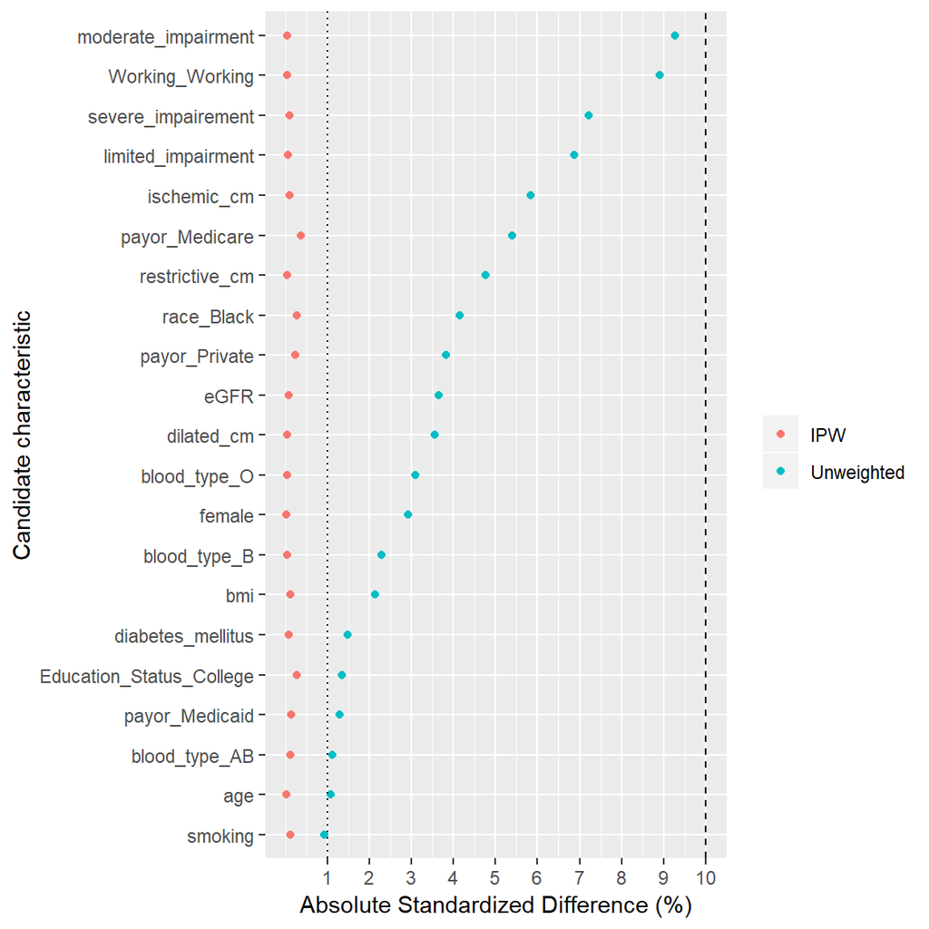

```r
# import the output of the convenient tebalance command, see propensity_score_analysis.do
stand_diffs <- read_csv("Stand_diffs.csv")


stand_diffs %>%
  arrange(abs(Unweighted)) %>%
  mutate(variable = factor(variable, levels = unique(variable))) %>%
  pivot_longer(cols = -variable, names_to = "Model", values_to = "Standardized Difference") %>%
  ggplot(aes(x = 100*abs(`Standardized Difference`), y = variable, color = Model)) +
  geom_point() +
  geom_vline(aes(xintercept = 10), linetype = "dashed") +
  geom_vline(aes(xintercept = 1), linetype = "dotted") +
  scale_x_continuous(breaks = seq(1:10)) +
  labs(x = "Absolute Standardized Difference (%)",
                      y = "Candidate characteristic",
                      color = "")
```

```r
ggsave("Figure_S2.pdf")
```

Code by Kevin Chung and William Parker

*William.Parker@uchospitals.edu*

*Kevin.Chung@uchospitals.edu*